# Praca domowa 7 - WUM

Patryk Wrona

16 czerwca 2020

# Wstęp, cele pracy

Celem niniejszej pracy będzie kompresja obrazka z użyciem PCA.

Rozważany obrazek:

[figure not shown]

Być może uda się odpowiedzieć na pytanie który z języków programowania jest bardziej ‘odporny’ na kompresję PCA, a który bardziej podatny.

# Wczytanie obrazka

```r
img <- readPNG( "RP.png")

# zapis liczby bitów w obrazku (wiersze x kolumny)
orginal_size <- length(img) # 555 x 459 = 1018980

# rozbicie komponentów R(red), G(green), B(blue)
r <- img[,,1]
g <- img[,,2]
b <- img[,,3]
```

# Użycie PCA dla każdego koloru odzielnie

```r
img.r.pca <- prcomp(r, center = FALSE)
img.g.pca <- prcomp(g, center = FALSE)
img.b.pca <- prcomp(b, center = FALSE)

rgb.pca <- list(img.r.pca, img.g.pca, img.b.pca)
```

# Zapis obrazów + obliczanie ich rozmiarów

```r
# W tej zmiennej przechowam liczbę najbardziej znaczących komponentów:
pcnum = c(1, 2, 4, 6, 8, 10, 20, 40, 60, 80, 100, 200)
# jest ich 12, więc trzeba będzie obliczyć rozmiar obrazka dla każdego ustawienia
compressed_size <- rep(0,12)
```

```r
k <- 0
for(i in pcnum){

  # kompresuje obrazek dla zadanej liczby głównych komponentów (pcnum)

  k <- k + 1
  pca.img <- sapply(rgb.pca, function(j) {
    compressed.img <- j$x[,1:i] %*% t(j$rotation[,1:i])
  }, simplify = 'array')
  writeJPEG(pca.img, paste0("R&Python_compressed_", i, '_components.jpg', sep = ''))

  # oblicza rozmiar stworzonego obrazka
  compressed_size[k] <- sum(
    sapply(rgb.pca, function(j) {
      length(j$x[,1:i]) + length(j$rotation[,1:i])
    }, simplify = 'array')
  )
}
```

Teraz sprawdzimy ile razy dany obrazek zmniejszył swoje wymiary (l. bitów)

```r
round(orginal_size / compressed_size, digits = 1)
```

```
##  [1] 335.0 167.5  83.7  55.8  41.9  33.5  16.7   8.4   5.6   4.2   3.3
## [12]   1.7
```

```r
# 335.0 167.5  83.7  55.8  41.9  33.5  16.7   8.4   5.6   4.2   3.3   1.7
```

# Wnioski - zysk na objętości & strata na jakości

Dla odpowiednich ilości głownych komponentów wyznaczam przybliżony zysk na objętości:

1 - 335 razy mniejsza objętość

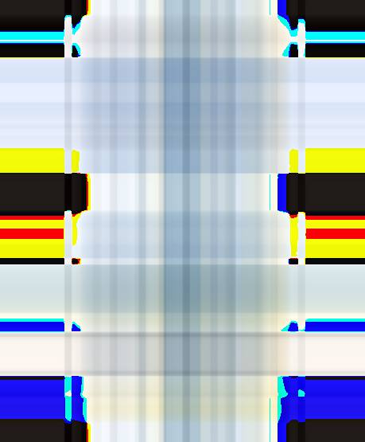

Z tego obrazka da się wywnioskować chyba tylko tyle, że ‘coś’ było w jego środku.

(2 - 167.5 razy mniejsza objętość)

4 - 83.7 razy mniejsza objętość

[figure not shown]

Tu już można przeczytać literę ‘R’, więc chyba mamy zwycięzcę. ;)

Oczywiście to pewnie dlatego, że to R jest olbrzymie. Na dole też już powoli można się domyślać, że chodzio Pythona - ze względu na kolory i powoli tworzące się już słowo ‘python’.

(6 - 55.8 razy mniejsza objętość)

8 - 41.9 razy mniejsza objętość

[figure not shown]

Tutaj już nie mamy wątpliwości odnośnie tego co było na orginalnym obrazku.

(10 - 33.5 razy mniejsza objętość)

20 - 16.7 razy mniejsza objętość

[figure not shown]

Obrazek zaczyna być coraz bardziej wyraźny.

(40 - 8.4 razy mniejsza objętość)

60 - 5.6 razy mniejsza objętość

[figure not shown]

Natomiast dla tej kompresji podobają mi się oczy węża ( zwłaszcza tego u góry).

(80 - 4.2 razy mniejsza objętość)

100 - 3.3 razy mniejsza objętość

[figure not shown]

Tutaj nie ma większej różnicy w przekazie informacji - od wcześniejszych już kompresji było wiadomo, że chodzi o R i Pythona. Znika tylko tło - robi się białe.

200 - 1.7 razy mniejsza objętość

[figure not shown]

Ta kompresja, zajmująca prawie 2 razy mniej objętości, jest prawie idealna w prównaniu do oryginalnego obrazka.

# Konkluzja

Udało mi się zastosować kompresję PCA do obrazka. Im więcej komponentów uwzględniałem, tym więcej ten obrazek zajmował miejsca, tylko że pewnie rozciągał się do oryginalnch wymiarów, przez co w rzeczywistości najwięcej miejsca zajmuje obrazek stworzony z 20 głownych komponentów. Najmniej miejsca zajmują obrazki o najgorszej i najlepszej jakości - czyli z użyciem 1 oraz 200 ‘principal components’ odpowiednio 23.8 KB oraz 15.5 KB.

# Oświadczenie

Oświadczam, że niniejsza praca stanowiąca podstawę do uznania osiągnięcia efektów uczenia się z przedmiotu *Wstęp do uczenia maszynowego* została wykonana przeze mnie samodzielnie.